# 9_3_1_stock_random_forest

Jilung Hsieh

2018/5/29

```r
browseURL("https://cfss.uchicago.edu/text_classification.html")
library(tidyverse)
library(tidytext)
library(stringr)

set.seed(1234)
theme_set(theme_minimal())
```

# Loading data

```r
load("data/stock_news.RData")
stock_news %>% names
```

```
##  [1] "newsId"    "title"     "publishAt" "content"   "words"
##  [6] "words0"    "time"      "code"      "status_p"  "status_v"
```

```r
library(jiebaR)
segment_not <- c("鴻海" ,  "永豐金", "中信金", "台積電", "聯發科" ,"兆豐金", "台指期","郭台銘","張忠謀","鉅亨網")
cutter <- worker()
new_user_word(cutter,segment_not)
```

```
## [1] TRUE
```

```r
stopWords <- readRDS("data/stopWords.rds")
```

# Stopwords

```r
unnested.df <- stock_news %>%
    select(doc_id = newsId, text = content, status = status_p) %>%
    mutate(word = purrr::map(text, function(x)segment(x, cutter))) %>%
    unnest(word) %>%
    filter(!is.na(word)) %>%
    anti_join(stopWords) %>%
    filter(!str_detect(word, "[a-zA-Z0-9]+")) %>%
    filter(nchar(word) > 1)
# bigram_unnested.df <- bigrams %>%
#   mutate(w_c = paste(V1, V2, sep=" ")) %>%
#   left_join(chi_df) %>%
#   filter(!is.na(chi2)) %>%
#   count(doc_id, word = w_c) %>%
#   left_join(select(stock_news, doc_id = newsId, status = status_p))
```

# DocumentTermMatrix

```r
(stock_dtm <- unnested.df %>%
   # get count of each token in each document
   count(doc_id, word) %>%
   # create a document-term matrix with all features and tf weighting
   cast_dtm(document = doc_id, term = word, value = n))
```

```
## <<DocumentTermMatrix (documents: 610, terms: 12935)>>
## Non-/sparse entries: 63195/7827155
## Sparsity           : 99%
## Maximal term length: 8
## Weighting          : term frequency (tf)
```

```r
  # cast_dtm(document = ID, term = word, value = n,
  #          weighting = tm::weightTfIdf)
```

# delete sparse terms

Another approach to reducing model complexity is to remove sparse terms from the model. That is, remove tokens which do not appear across many documents. It is similar to using tf-idf weighting, but directly deletes sparse variables from the document-term matrix. This results in a statistical learning model with a much smaller set of variables.

```r
stock_dtm <- tm::removeSparseTerms(stock_dtm, sparse = .99)
```

# EDA

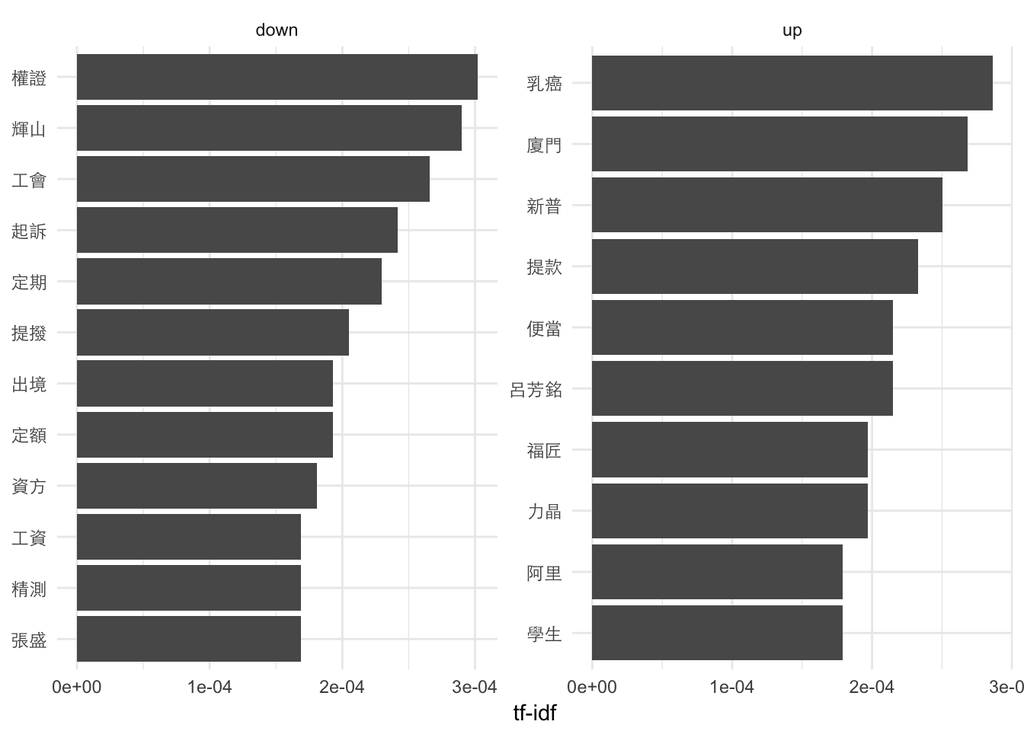

```r
word_tfidf <- unnested.df %>%
   count(status, word) %>%
   bind_tf_idf(word,  status, n)

plot_tfidf <- word_tfidf %>%
  arrange(desc(tf_idf)) %>%
  mutate(word = factor(word, levels = rev(unique(word))))

# graph the top 10 tokens for 4 categories
plot_tfidf %>%
  mutate(status = factor(status, levels = c(0,1),
                        labels = c("down", "up"))) %>%
  group_by(status) %>%
  top_n(10) %>%
  ungroup() %>%
  ggplot(aes(word, tf_idf)) +
  geom_col() +
  labs(x = NULL, y = "tf-idf") +
  facet_wrap(~status, scales = "free") +
  coord_flip() +
      theme(axis.text.y = element_text(family = "Heiti TC Light"))
```

# random forest

```r
library(caret)
# time-consumed
stock_rf <- train(x = as.matrix(stock_dtm),
                     y = factor(stock_news$status_p),
                     method = "rf",
                     ntree = 200,
                     trControl = trainControl(method = "oob"))

??train
```

- https://en.wikipedia.org/wiki/Out-of-bag_error: Out-of-bag (OOB) error, also called out-of-bag estimate, is a method of measuring the prediction error of random forests, boosted decision trees, and other machine learning models utilizing bootstrap aggregating (bagging) to sub-sample data samples used for training. OOB is the mean prediction error on each training sample xᵢ, using only the trees that did not have xᵢ in their bootstrap sample.[1]
- http://blog.sina.com.cn/s/blog_4c9dc2a10102vl24.html: 对于构建第k棵树时候没有用到的每条记录，让它们过一遍第k棵树，进而获得一个分类.通过这种方法, 对任何一条记录来说，大概有1/3 的树没有用这条记录来构建，因而对这些树可以进行测试集上的数据分类。最终, 假设 类别j 是当记录n是oob时候，获得投票最多的类别，j被错误分类除以总记录数n，就是 oob error estimate. 这在很多测试中被证明是无偏的[2].
- mtry 即為每顆決策樹之節點分支以隨機方式選擇屬性之個數

  ```
  Call:
   randomForest(x = x, y = y, ntree = 200, mtry = param$mtry)
             Type of random forest: classification
                   Number of trees: 200
  No. of variables tried at each split: 1827

      OOB estimate of  error rate: 38.52%
  Confusion matrix:
  0  1 class.error
  0 286 78   0.2142857
  1 157 89   0.6382114
  ```

```r
stock_rf$finalModel
```

```
##
## Call:
##  randomForest(x = x, y = y, ntree = 200, mtry = param$mtry)
##                Type of random forest: classification
##                      Number of trees: 200
## No. of variables tried at each split: 60
##
##         OOB estimate of  error rate: 40.33%
## Confusion matrix:
##     0  1 class.error
## 0 281 83   0.2280220
## 1 163 83   0.6626016
```

```r
knitr::kable(stock_rf$finalModel$confusion)
```

|  | 0 | 1 | class.error |
| --- | --- | --- | --- |
| 0 | 281 | 83 | 0.2280220 |
| 1 | 163 | 83 | 0.6626016 |

# Evaluating results

- `importance()` to calculate importance of vars
- Vars with higher Mean Decrease Gini are more important.
- Package: `randomForest` for Classification and Regression with Random Forest. `randomForest` implements Breiman’s random forest algorithm (based on Breiman and Cutler’s original Fortran code) for classification and regression. It can also be used in unsupervised mode for assessing proximities among data points.

```r
library(randomForest)
randomForest::importance(stock_rf$finalModel)
```

[output not shown]

[output cut: 1773 more lines]

[output not shown]

[figure not shown]

```r
randomForest::varImpPlot(stock_rf$finalModel, family = "Heiti TC Light")
```